# LING 3300 - Tutorial 3

Thomas Kettig

September 18, 2026

First, as always, let’s load in the packages and dataset we’ll be working with for these examples. To start, let’s use the jury dataset.

```r
library(tidyverse)
```

```r
jury <- read.csv("/Users/Thomas/Library/CloudStorage/OneDrive-YorkUniversity/LING 3300/Datasets/Jury/jury_data_basic.csv")
```

## Data visualization in R with ggplot2

It’s possible to do a lot of decent **data visualisation** just using Base R (that is, just the functions that come pre-loaded with R). [YaRrr! Chapter 11.1-11.5](https://bookdown.org/ndphillips/YaRrr/plotting1.html) demonstrates some of this Base-R plotting. But tidyverse contains a package called [ggplot2](https://ggplot2.tidyverse.org/) (commonly referred to as just “ggplot”) which adds flexibility and has been widely adopted by linguists and other scientists. If you have installed tidyverse and loaded it in using the library() or require() functions, then ggplot2 will automatically be loaded too. You can read more about the background to ggplot2 [here](https://qz.com/1007328/all-hail-ggplot2-the-code-powering-all-those-excellent-charts-is-10-years-old/).

ggplot code is fairly templatic, and works by creating “layers” to a plot. You will always need the following three components in your ggplot code:

- the ggplot() function that tells R you want to create a graph with some data frame
- the geom_X() function where X refers to the specific type of plot you want to make (histogram, scatterplot, etc.). We’ll go over some possible geom_X functions below
- an aesthetics mapping aes() that tells R how to arrange the variables on the plot

### Histograms

When you want to plot the distribution of **one continuous variable**, you can use a histogram. Here, we’ll demonstrate with participants’ self-rating of familiarity with Standard Southern British English. (Let’s set aside debates over whether Likert-style ordinal ratings are truly quantitative, and treat this variable as continuous.)

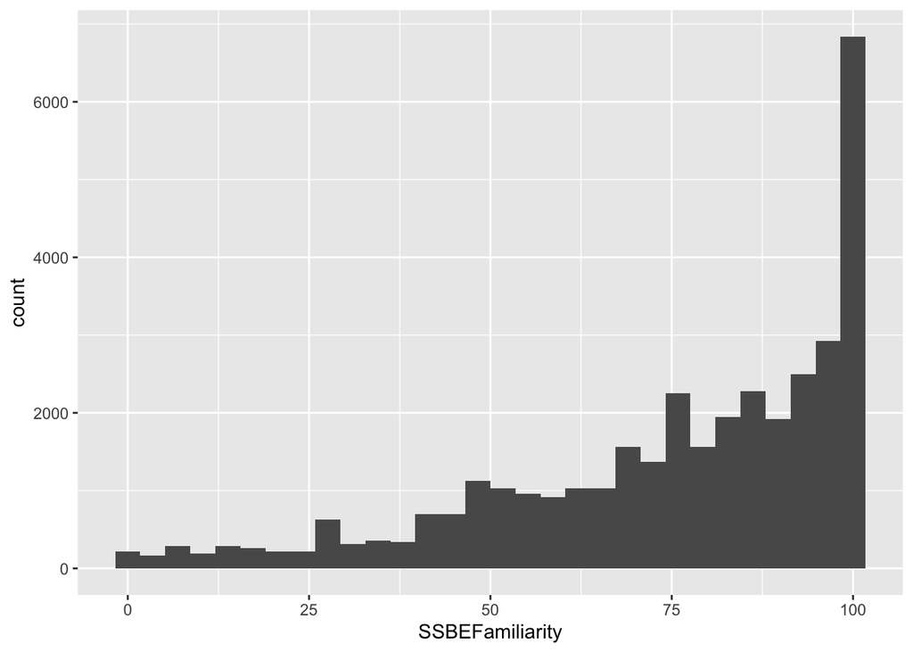

```r
ggplot(jury) +
  geom_histogram(aes(x = SSBEFamiliarity))
```

As we can see, most people rate themselves as very familiar with SSBE.

### Density plots

Density plots are very similar to histograms, but instead of dealing with bins of observations and their raw counts, these estimate “kernel density”. No need to know what this is, but basically this is just a smoothed version of a histogram.

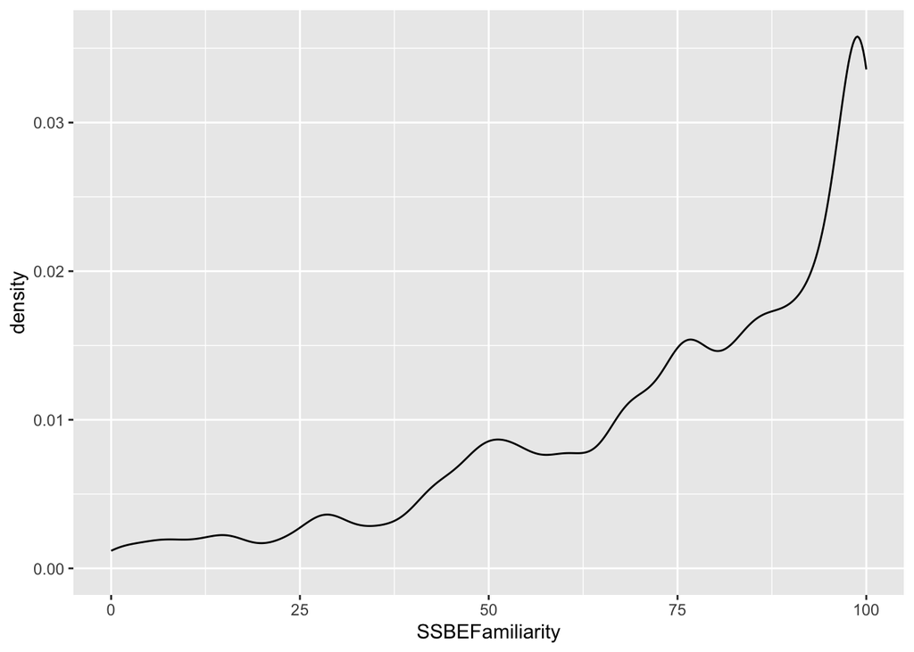

```r
ggplot(jury) +
  geom_density(aes(x = SSBEFamiliarity))
```

### Boxplots

When you want to plot the distribution of one continuous variable, but for separate categories, you can use a boxplot.

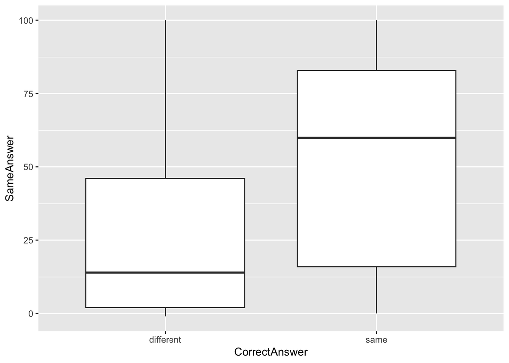

```r
ggplot(jury) +
  geom_boxplot(aes(x = CorrectAnswer, y = SameAnswer))
```

Here, we can see that listeners’ answers on a 0-100 scale for the question “Are these the same or different people?” differ by whether the pair was actually the same or different; when the correct answer is that they’re different people, respondents give lower ratings for sameness than when the correct answer is that they’re the same person.

### Scatterplots

When you have **two continuous variables** and you want to show the relationship between them, you’ll want a scatterplot. Think carefully about which variable you’ll want on the x-axis, and which one on the y-axis:

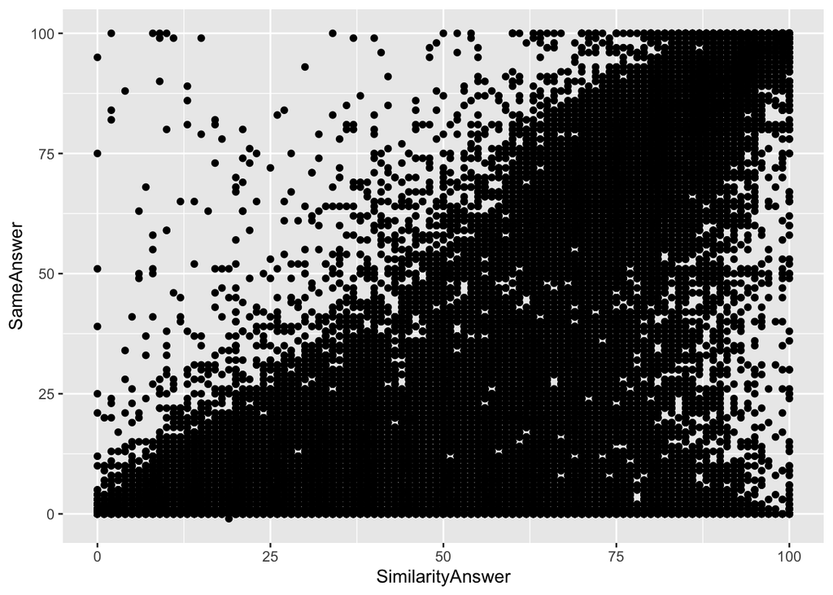

```r
ggplot(jury) +
  geom_point(aes(x = SimilarityAnswer, y = SameAnswer))
```

Here we’re plotting people’s 0-100 answer to “How similar are these voices” on the x-axis and their 0-100 answer to “Are these the same or different people?” on the y-axis. In RStudio, kyou can click the “Zoom” button in the Plots tab to see a larger version of the plot. One of the things we see here is that if people give low ratings for similarity, they’re very unlikely to give high ratings for sameness. There seems to be more instances of people giving high ratings for voice similarity but also saying they’re pretty sure that they’re not actually the same person.

### Bar graphs

When you want to display the **count or proportion** of different levels of a categorical variable, you’ll want a bar graph:

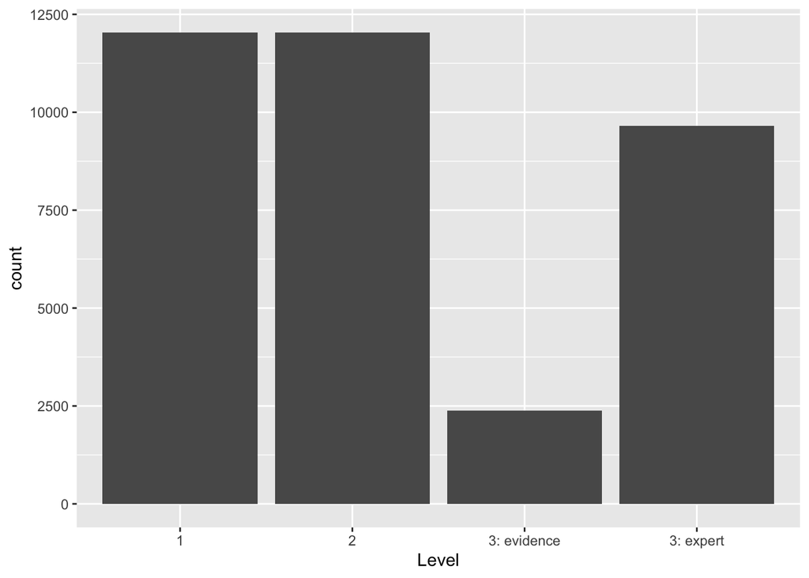

```r
ggplot(jury) +
  geom_bar(aes(x = Level))
```

We see here that when this experiment was run, we collected equal amounts of data for Level 1 (when it’s boring and beige) and Level 2 (when we first introduce the jury vs. robot scenario). Because we had two versions of Level 3 which we ran on different participants, we have less data for each of those levels. We have a small amount of data for a version of Level 3 where we gave listeners an extra piece of “evidence” in the “case” (showing them a little picture of a DNA strand, footprint, or fingerprint); we have a larger amount of data for the version of Level 3 where we gave listeners access to an “expert witness” who supplied them with “testimony” in favour of the voices belonging to the same or to different people.

### Layering

#### Facetting

Let’s say we want a separate scatterplot looking at the relationship between similarity and sameness rating for each correct answer condition **separately**. We can use facet_wrap(~CorrectAnswer) to split this up:

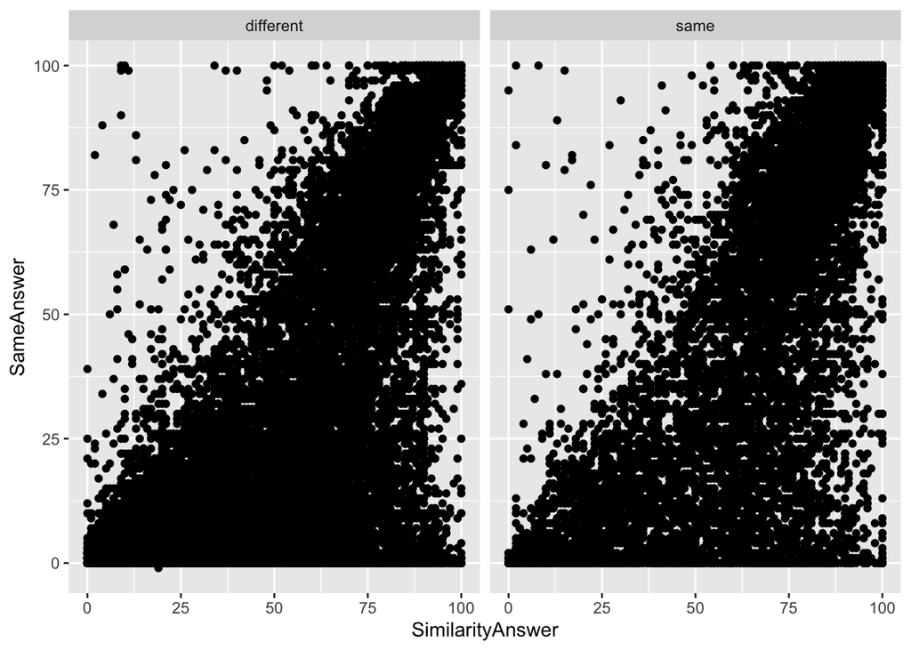

```r
ggplot(jury) +
  geom_point(aes(x = SimilarityAnswer, y = SameAnswer)) +
  facet_wrap(~CorrectAnswer)
```

You can combine facet_wrap() with any plot. Here’s an example with a histogram:

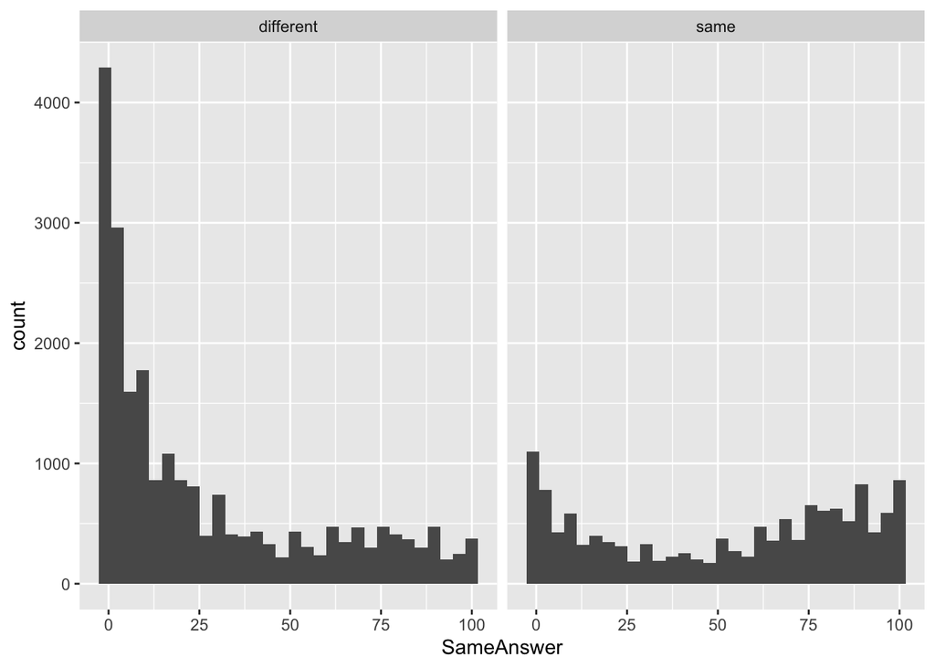

```r
ggplot(jury) +
  geom_histogram(aes(x = SameAnswer)) +
  facet_wrap(~CorrectAnswer)
```

For every five different-speaker sound pairs in this experiment there were just three same-speaker pairs, so the raw numbers for the different-speaker conditions are higher. That being said, it is also apparent here that the same-speaker pairs were trickier for listeners than the different-speaker pairs. The mode of the different-speaker pair distribution is clearly very low; for the same-speaker pairs, the sameness answers seem to be bimodally distributed, showing about the same number of high sameness ratings as low ratings. We can plot these as density plots instead of histograms to verify that the shape of the same-answer distribution is more strongly bimodal than the different-answer distribution.

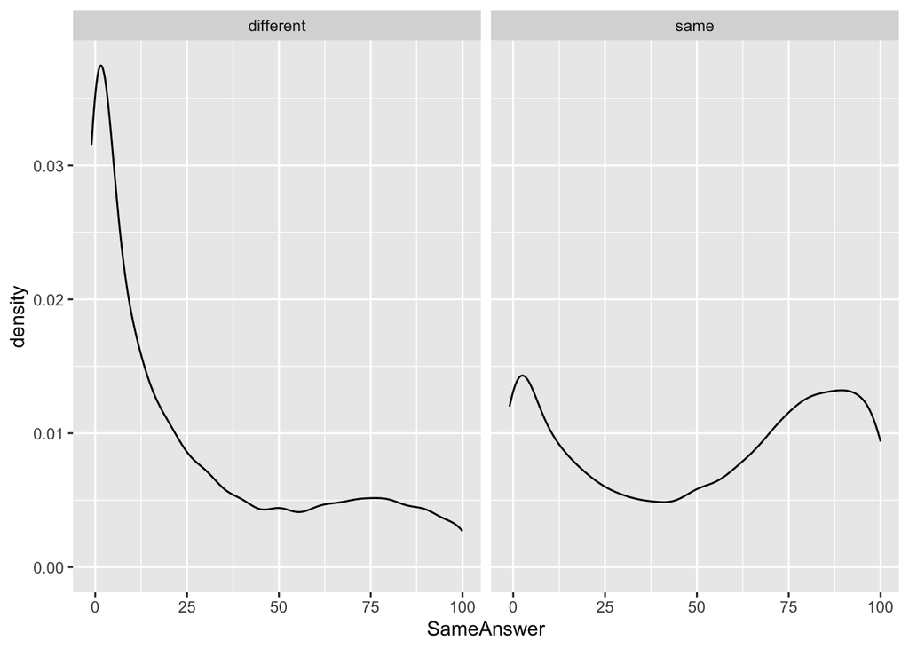

```r
ggplot(jury) +
  geom_density(aes(x = SameAnswer)) +
  facet_wrap(~CorrectAnswer)
```

#### Axis labels

It’s important to put informative labels on your x- and y-axes, and your column names might not provide that. You can use the xlab() and ylab() functions to add an axis label.

For example:

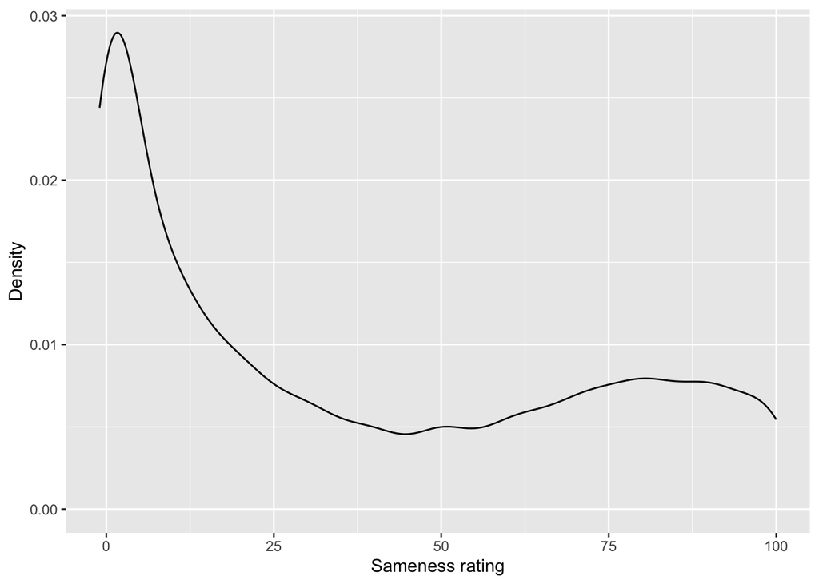

```r
ggplot(jury) +
  geom_density(aes(x = SameAnswer)) +
  xlab("Sameness rating") +
  ylab("Density")
```

#### Axis limits

Sometimes you want to truncate the displayed data on the axes, or make sure it’s very consistent. You can specify an exact range by using the functions xlim(number1, number2) and/or ylim(number1, number2). Compare the plots below. Perhaps we want to just zoom in on the SSBE familiarity responses above 75, in which case we could set the x-axis limits to be between 75 and 101 (or any maximum more than 100 – setting it to 100 would exclude all the reponses that were exactly 100, which wouldn’t be good.) Or we could zoom in on just lower responses and manually select a y-axis range.

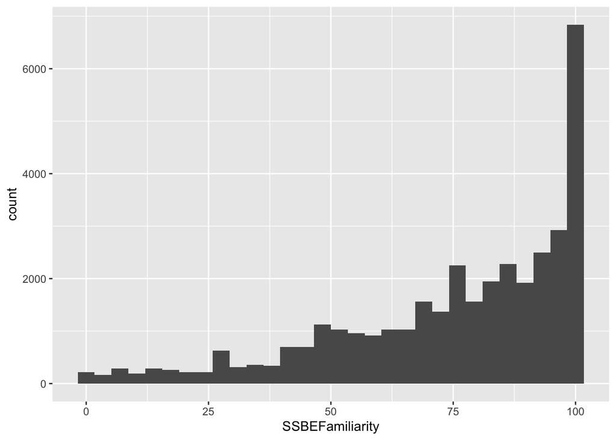

```r
ggplot(jury) +
  geom_histogram(aes(x = SSBEFamiliarity))
```

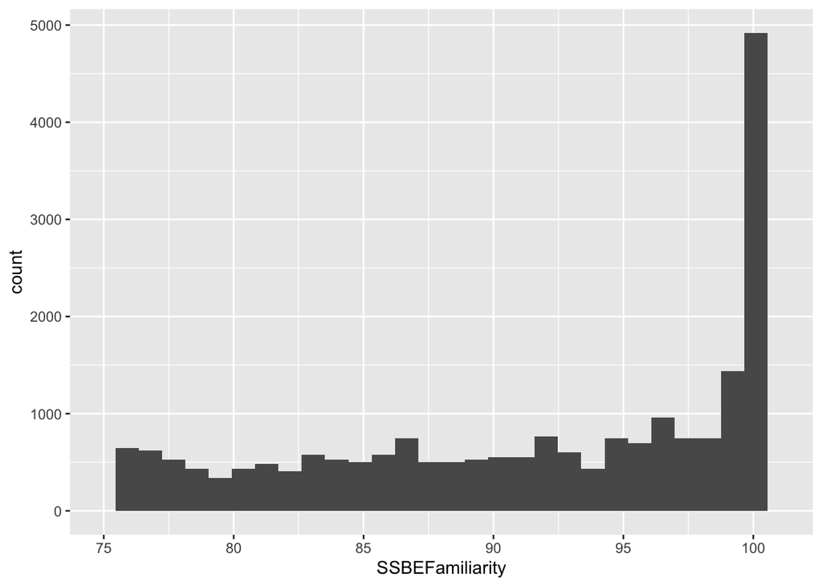

```r
ggplot(jury) +
  geom_histogram(aes(x = SSBEFamiliarity)) +
  xlim(75, 101)
```

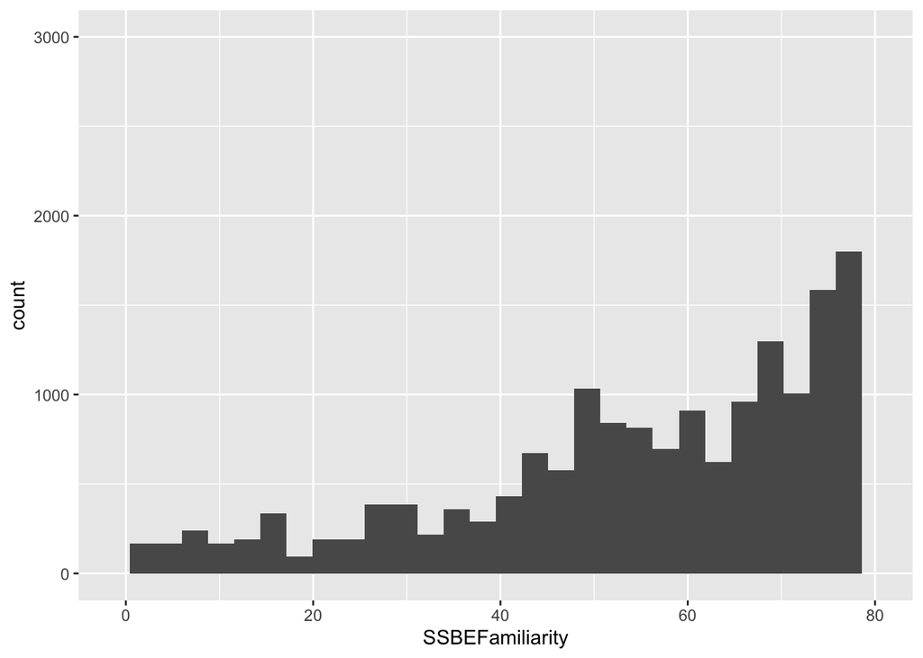

```r
ggplot(jury) +
  geom_histogram(aes(x = SSBEFamiliarity)) +
  xlim(-1, 80) +
  ylim(-1, 3000)
```

#### Colors

There are [so many colors in R!](http://www.stat.columbia.edu/~tzheng/files/Rcolor.pdf)

There are confusingly two ggplot arguments that will make use of color:

- the **color** argument
- the **fill** argument

The color argument actually just changes the outline color. The fill argument will refer to the color of a column in e.g., a bar graph or histogram.

We’ll first start with an example where we keep the outline color **constant** across every variable in the figure. When you want everything to be the same color, you put the color variable **outside** of the aes() function, but within the geom_X() function:

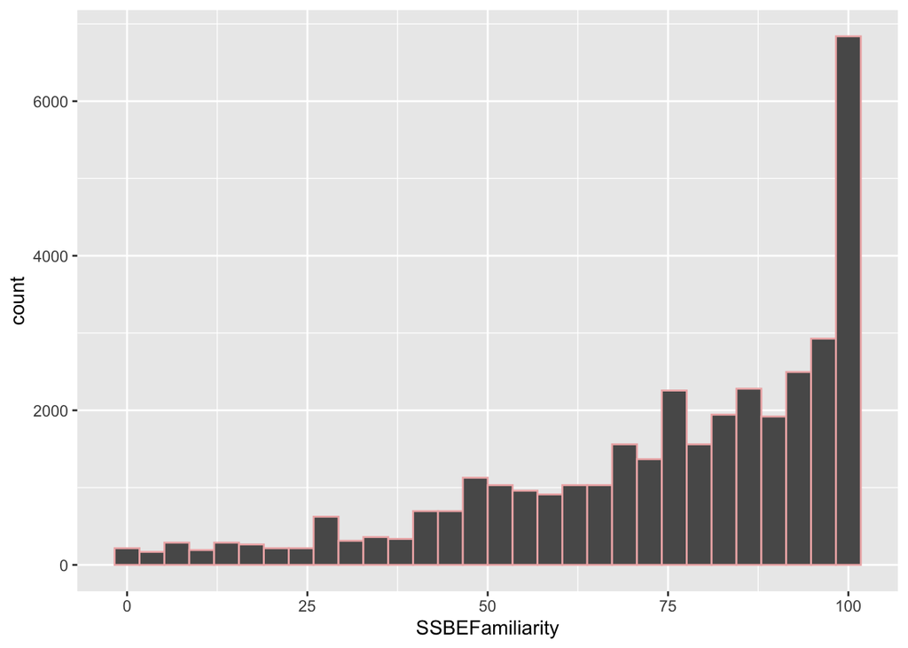

```r
ggplot(jury) +
  geom_histogram(aes(x = SSBEFamiliarity), color = "rosybrown2")
```

We can do the exact same thing with **fill**. Note the difference:

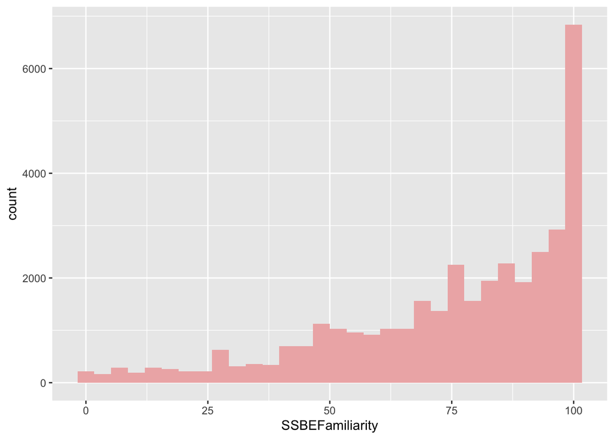

```r
ggplot(jury) +
  geom_histogram(aes(x = SSBEFamiliarity), fill = "rosybrown2")
```

You can also combine the two; order doesn’t matter:

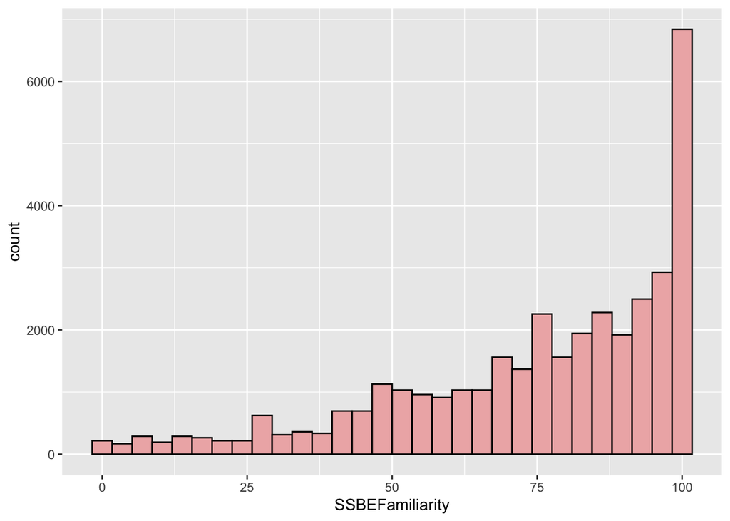

```r
ggplot(jury) +
  geom_histogram(aes(x = SSBEFamiliarity), color = "black", fill = "rosybrown2")
```

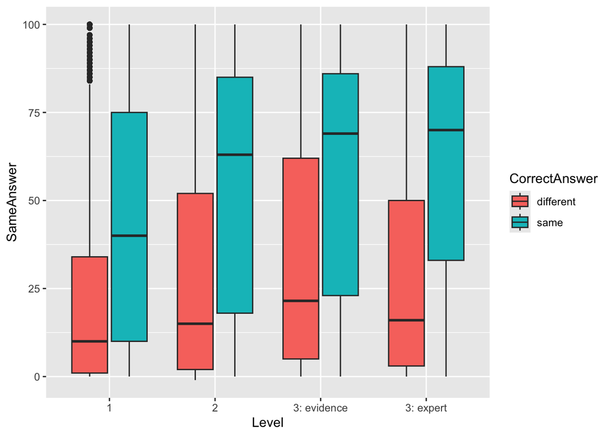

```r
ggplot(jury) +
  geom_boxplot(aes(x = Level, y = SameAnswer, fill = CorrectAnswer))
```

Further examples:

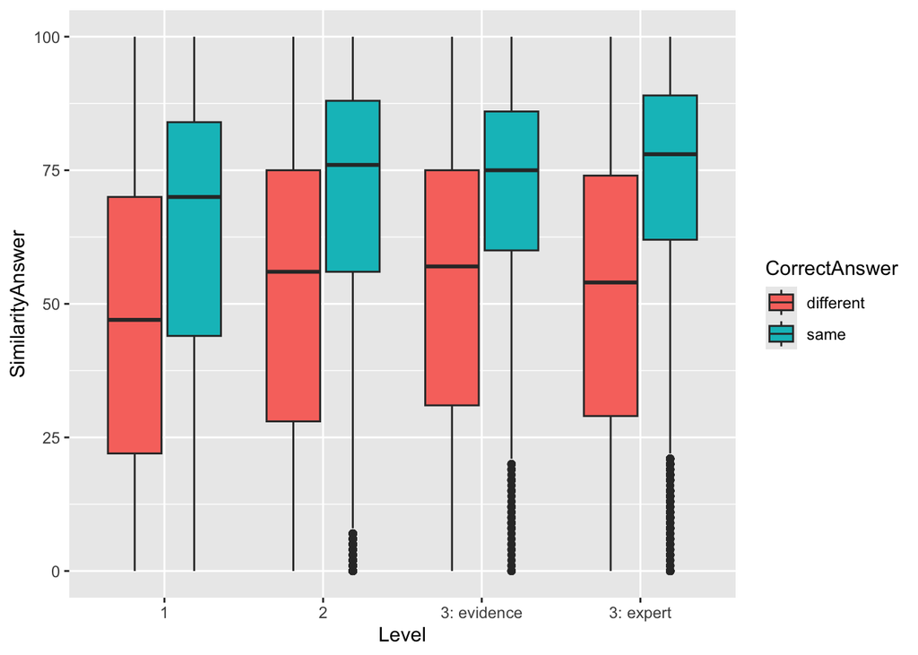

```r
ggplot(jury) +
  geom_boxplot(aes(x = Level, y = SimilarityAnswer, fill = CorrectAnswer))
```

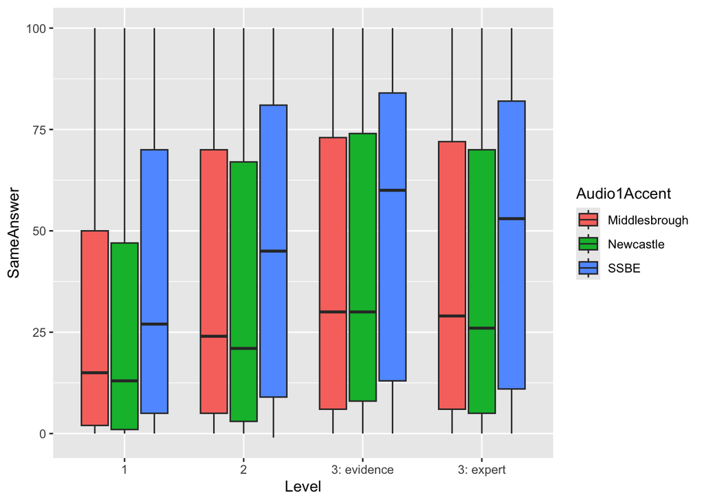

```r
ggplot(jury) +
  geom_boxplot(aes(x = Level, y = SameAnswer, fill = Audio1Accent))
```

#### Change the color of the mapping

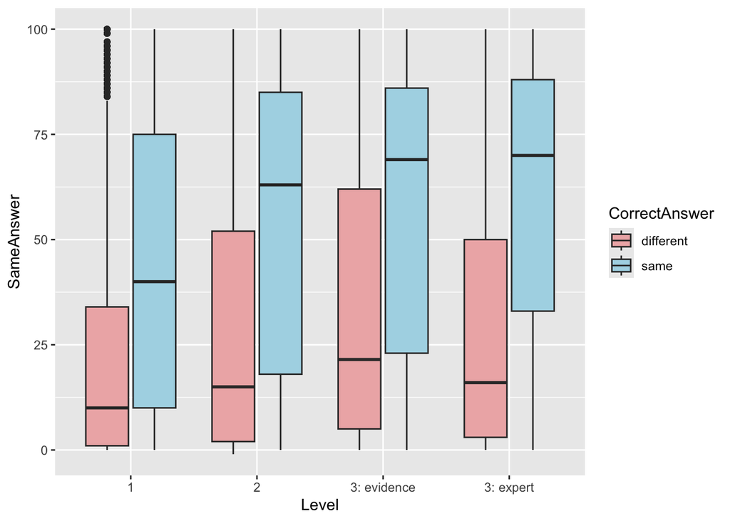

```r
ggplot(jury) +
  geom_boxplot(aes(x = Level, y = SameAnswer, fill = CorrectAnswer)) +
  scale_fill_manual(values = c("rosybrown2", "lightblue"))
```

There are also some automatic color scales in R, and ones that work for colorblindness, etc. Some more info can be found by googling “color palettes” in R, and some good examples are on [this page](https://www.datanovia.com/en/blog/top-r-color-palettes-to-know-for-great-data-visualization/).

#### Background theme

You can change the “theme” of the R plot, which generally includes the background color, the presence of grid lines, the font size, and a few other things using some theme_X() functions. The default theme with the gray background is theme_gray(); many people like the theme_bw() or theme_classic() backgrounds. There are several more theme_X() options in the ggthemes package if you’d like to install that and experiment. Here you can see what it looks like with the theme_classic() function. You can put the font size in the parentheses if you want, or leave a number out and have it choose a default size. Note also the specification of the binwidth in this histogram, if you wanted to specify that bins should be 10 units wide:

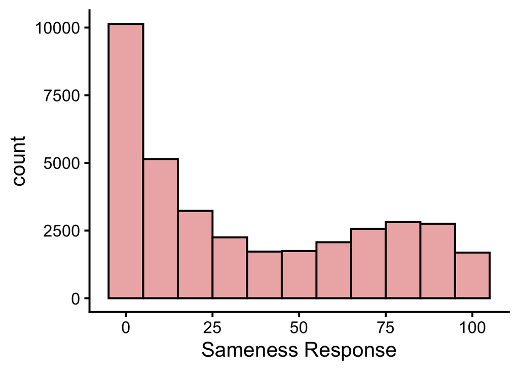

```r
ggplot(jury) +
  geom_histogram(aes(x = SameAnswer), fill = "rosybrown2", color = "black", binwidth = 10) +
  xlab("Sameness Response") +
  theme_classic(20)
```

### Saving images

You can save an image using various file formats. The simplest way to save an image is to click on the Export… button in the Plots panel. You should have the option save either as a PNG or as a PDF file there. You may need to play around with the sizes and settings to get one that’s a decent resolution for PNGs. The Export option for Save as PDF is a little easier to work with, but note that PDF images often **do not** transfer well between Mac and Windows computers.

An alternative to clicking around at the bottom right is to use the ggsave() function. You specify the name and location of the new file you want to create, and then the height and width in inches and the resolution you’d like it to be (usually 300 is fine).

```r
ggsave("/Users/Thomas/Library/CloudStorage/OneDrive-YorkUniversity/LING 3300/Datasets/Jury/plot1.png", width = 7, height = 7, dpi = 300)
```

#### Data visualization practice

1. Load in ‘L2_English_Lexical_Decision_Data.csv’ again R and call it ‘lex’, so we’re starting over from the original dataset.
2. Create a histogram of the reaction times (RT column). It will probably look weird because of the extreme range of RTs.
3. Get a summary of the RT values, and take a look at the maximum value. Something can’t be right there.
4. Create another histogram of the reaction times where the x-axis only includes values from 0 to 5000 ms.
5. Based on the histogram, it looks like values above 2500 seem pretty improbable. Create a subset of lex which only retains reaction times below 2500 ms. Call this lex again.
6. Create another histogram of reaction times using the new dataset and change the background theme, along with the outline color and fill of the bars.
7. Let’s say we’re interested in comparing reaction times of L1 English speakers against L2 English speakers. Create a new column called ‘L2’ that indicates whether a speaker’s dominant language is English or not.
8. Create a boxplot with L2 status on the x-axis and the reaction time on the y-axis.
9. Let’s also say we might want to look at any potential effects of gender. Create another column in lex called ‘gender’. If the sex of the participant is equal to 1, then the new value in the ‘gender’ column should be “m” for male, otherwise the new value should be “f”.
10. Recreate the same boxplot in 8, but use the aesthetic mapping to map color to the gender column.
11. Now recreate the same boxplot, but also provide more descriptive axis labels.
12. Create a new column called ‘accuracy’. If the column ‘acc’ is equal to 1, then the value in ‘accuracy’ should be equal to “right”, otherwise the value should be equal to “wrong”.
13. Create a bar graph with accuracy on the x-axis and the fill of the bar mapped to the L2 status. This should create what’s called a “stacked” bar graph, where the number of “right” answers for L1 English speakers is stacked on top of the number of “right” answers for L2 English speakers.
14. To create a “dodged” bar graph where the bars are **next to each other**, you’ll need to use the following argument:

```r
geom_bar(aes(x = accuracy, fill = L2), position = "dodge")
```

15. Now take the same graph from 14 and change the colors and background theme.

Disclaimer: Some of these original materials were put together by Eleanor Chodroff and Elisa Passoni for the University of York. Thomas Kettig then inherited it and modified as needed, particularly based on notes by Nathan Sanders from the University of Toronto. The R software and the packages are distributed under the terms of the GNU General Public License, either Version 2, June 1991 or Version 3, June 2007 (run the command licence () for more information)